# 통계밥법론2 Chap1,2 실습코드

202140191 엄태훈

2021-09-11(SAT)

# Chap1 Introduction

일반적으로 데이터 분석을 진행한다는 것은, 데이터 수집부터 결과 도출까지의 모든 과정을 일컫는다.  
이렇게 얻어진 결과들을 정리하여 우리는 다수의 사람들 앞에서 데이터를 통해 얻어진 결론이 무엇인지 설명하는 것이 필요하다.  
그렇다면, 이때 가장 중요하게 여겨지는 요소가 무엇일까? 데이터의 분포, 모델의 성능, 분석기법 등을 생각해볼 수 있을 것이다. 하지만, 우리는 여기서 다수의 사람들이 통계를 전공한 사람들이 아닐수도 있다는 사실을 알아야한다. 복잡하고 어려운 분석기법과 모델의 성능에 대해서 아무리 설명을해도 그들에게는 크게 와닿지 않을 수도 있다. 따라서, 이러한 경우 가장 중요하게 여겨지는 요소가 바로 **시각화(Visualization)**이다.

우리가 전달하고자 하는 내용과 데이터들은 수많은 숫자 혹은 글로 구성돼있기 때문에 비전공자들이 해석하기에는 상당히 어려움이 따를수도 있다.

**시각화**는 이렇게 데이터 또는 분석결과를 조금 더 쉽게 이해하고 한 눈에 볼 수 있도록 시각적인 요소를 나타내는 방법을 말한다. 이때, 통계에서 데이터 분석을 진행하기 전에 시각화를 통해 데이터를 살펴보는 방법을 **탐색적 자료분석(Exploratory Data Analysis)**라고 한다.

특히, 데이터와 결론이 복잡해질수록 이러한 시각화 능력이 굉장히 중요시되기 때문에, 상황에 맞는 다양한 시각화 기법을 익히는 것은 데이터 분석가에게 있어서 매우 중요하게 여겨지는 능력 중 하나라고 할 수 있다.

통계에서 변수는 값을 숫자로 나타낼 수 있는 **양적변수(Quantitative variable)**와 변수의 값을 특정 범주에 포함시키는 **질적변수(Quantitative variable)**으로 나눠진다. 질적변수는 **범주형 변수**라고하기도 한다.

## 1.2 What is categorical data?

**범주형 변수(Categorical data)**는 순서가 지정(**순서형 변수**)되거나 순서가 지정되지 않은 범주(**명목형 변수**)의 이산 집합으로 나눌 수 있다.

범주형 변수의 예시는 다음과 같이 생각할 수 있다.

EX)

- Gender: “Male”, “Female”
- Marital status: “Never married”, “Married”, “Separated”, “Divorced”, “Widowed”
- Fielding position(baseball): “Pitcher”, “Catcher”, “1st base”, “2nd base”, …“Left field”

**범주형 데이터(Categorical data)**는 우리가 많이 접해본 양적인 데이터와는 다른 변수의 값을 가지고 있으므로, 이에 따른 적합한 통계분석 및 시각화 방법을 익히는 것이 필요하다.

```r
library(vcd)
data("Arthritis")
head(Arthritis,5)
```

```
##   ID Treatment  Sex Age Improved
## 1 57   Treated Male  27     Some
## 2 46   Treated Male  29     None
## 3 77   Treated Male  30     None
## 4 17   Treated Male  32   Marked
## 5 36   Treated Male  46   Marked
```

`vcd`패키지는 시각화 기법, 데이터셋의 요약 및 추론절차를 간편하게 할 수 있는 패키지로, 특히 범주형 데이터를 다룰때 유용하게 사용할 수 있다.

`Arthritis`데이터는 `vcd`패키지에 있는 데이터로, 류마티스 관절염의 새로운 치료법에 대한 데이터이다. 84개의 관측값과 5개의 변수로 이루어진 데이터이다.

- ID: 환자의 ID (Norminal variable)
- Treatment: 치료 약의 요인 (Factor variable - Placebo, Treated)
- Sex: 성별 (Factor variable - Female, Male)
- Age: 나이 (Discrete variable)
- Improved: (Ordered Factor variable - None, Some, Marked)

`vcd`패키지에서 `Arthritis` 데이터를 로드한 후, `head`함수를 이용하여 데이터를 살펴본다.

```r
library(dplyr)
Arthritis %>%
  group_by(Treatment,Sex,Improved) %>%
  summarise(Freq=n())
```

```
## # A tibble: 11 x 4
## # Groups:   Treatment, Sex [4]
##    Treatment Sex    Improved  Freq
##    <fct>     <fct>  <ord>    <int>
##  1 Placebo   Female None        19
##  2 Placebo   Female Some         7
##  3 Placebo   Female Marked       6
##  4 Placebo   Male   None        10
##  5 Placebo   Male   Marked       1
##  6 Treated   Female None         6
##  7 Treated   Female Some         5
##  8 Treated   Female Marked      16
##  9 Treated   Male   None         7
## 10 Treated   Male   Some         2
## 11 Treated   Male   Marked       5
```

`dplyr`패키지는 R에서 데이터 프레임에 대한 전처리 과정을 빠르고 유용하게 진행하고자 할때, 사용하는 패키지이다.

`dplyr`패키지를 불러오면 **파이프라인**이라고 불리는 `%>%`를 사용할 수 있고, 이를 통해 데이터 처리를 훨씬 간편하게 할 수 있으며, 코드 또한 깔끔한 형태로 만들 수 있다.

`group_by`함수는 묶고자 하는 그룹들의 변수를 지정하여 그룹별로 데이터를 묶어준다.  
- `group_by(data)`

- data: 묶고자하는 데이터의 변수

`summarise`함수는 새로운 데이터를 생성할 수 있는데, 특히 `group_by`함수를 통해 그룹별로 묶어진 데이터들의 요약값을 살펴보는데 유용하게 사용할 수 있다.  
- `summarise(create = function(columns))`

- create: 만들고자하는 변수의 이름
- function: 요약값을 구할 수 있는 함수
- columns: 요약값을 보고자 하는 변수

위의 코드는 **Treatment, Sex, Improved**을 그룹으로 묶고 그에 따른 데이터의 빈도수를 구하는 코드이다.

**Treatment = Placebo, Sex = Female, Improved = None**인 환자의 빈도는 19로 가장 많다.  
**Treatment = Placebo, Sex = Male, Improved = Marked**인 환자의 빈도는 1로 가장 적다.

```r
Arthritis %>%
  group_by(Treatment,Improved) %>%
  summarise(Freq=n())
```

```
## # A tibble: 6 x 3
## # Groups:   Treatment [2]
##   Treatment Improved  Freq
##   <fct>     <ord>    <int>
## 1 Placebo   None        29
## 2 Placebo   Some         7
## 3 Placebo   Marked       7
## 4 Treated   None        13
## 5 Treated   Some         7
## 6 Treated   Marked      21
```

**Treatment, Improved**를 그룹으로 묶고 그에 따른 데이터의 빈도수를 살펴본다.  
**Treatment = Placebo, Improved = None** 환자의 빈도는 29로 가장 많다.  
**Treatment = Placebo, Improved = Some**, **Treatment = Placebo, Improved = Marked**, **Treatment = Treated, Improved = Some**인 환자의 빈도는 7로 가장 적다.

```r
Arthritis %>%
  group_by(Sex) %>%
  summarise(Average_Age_by_Sex = mean(Age))
```

```
## # A tibble: 2 x 2
##   Sex    Average_Age_by_Sex
## * <fct>               <dbl>
## 1 Female               53.5
## 2 Male                 53
```

`summarise`함수의 `mean`함수를 활용하여 성별에 따른 환자들의 평균 나이도 살펴볼 수 있다.

## 1.3 Strategies for categorical data analysis

```r
data("HairEyeColor")
HairEyeColor
```

```
## , , Sex = Male
##
##        Eye
## Hair    Brown Blue Hazel Green
##   Black    32   11    10     3
##   Brown    53   50    25    15
##   Red      10   10     7     7
##   Blond     3   30     5     8
##
## , , Sex = Female
##
##        Eye
## Hair    Brown Blue Hazel Green
##   Black    36    9     5     2
##   Brown    66   34    29    14
##   Red      16    7     7     7
##   Blond     4   64     5     8
```

`HairEyeColor`데이터는 592명의 통계학과 학생들의 눈과 머리 색깔에 대한 분포를 나타낸 분할표이다.  
성별, 눈의 색깔, 머리의 색깔 총 3개의 변수로 구성돼 있다.

- Sex: 성별 (Factor variable - Male, Female)
- Hair Color: 머리의 색깔 (Factor variable - Black, Brown, Red, Blond)
- Eye Color: 눈의 색깔 (Facotr variable - Brown, Blue, Hazel, Green)

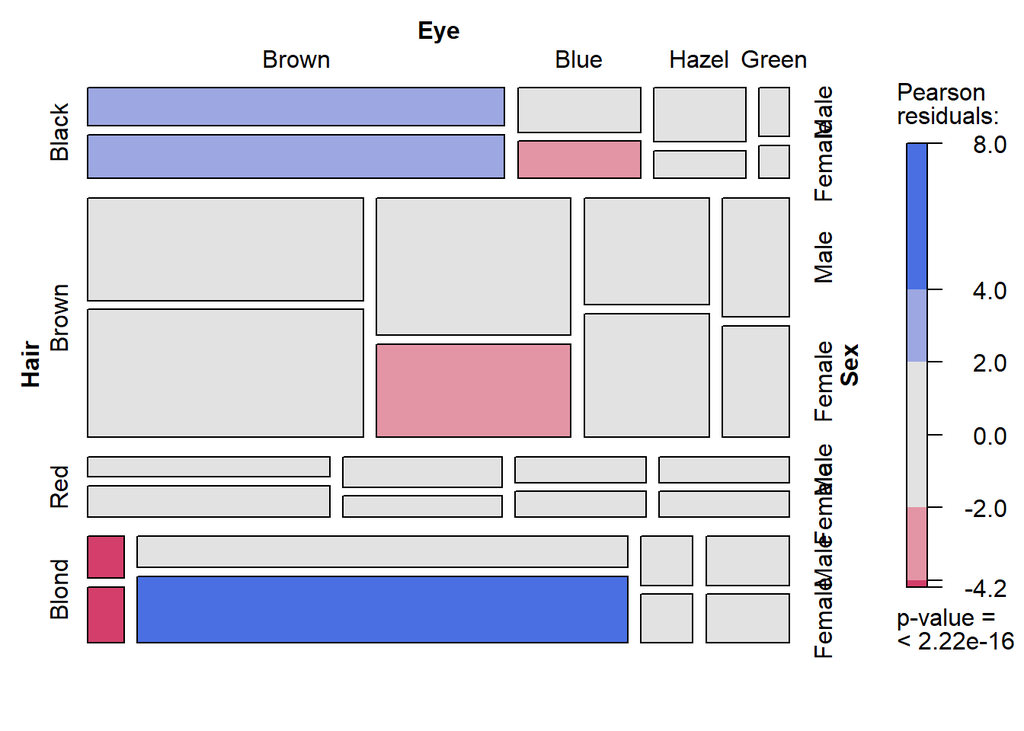

```r
mosaic(HairEyeColor,shade=TRUE)
```

`vcd`패키지의 `mosaic`함수를 통해 `mosaic plot`을 그려보았다.  
`mosaic plot`에 대한 내용은 뒤에 챕터에서 더 자세히 살펴보기 때문에 그때 다시 한 번 알아보도록 한다.

```r
Hair_eye_data <- HairEyeColor[,,"Female"] + HairEyeColor[,,"Male"]
chisq.test(Hair_eye_data)
```

```
##
##  Pearson's Chi-squared test
##
## data:  Hair_eye_data
## X-squared = 138.29, df = 9, p-value < 2.2e-16
```

`HairEyeColor`의 남성의 빈도와 여성의 빈도를 합쳐 **Hair_eye_data**에 저장한다.

`chisq.test`함수는 분할표에 대한 적합도 검정을 피어슨 카이제곱 통계량과 유의확률을 통해 확인할 수 있게 해주는 함수이다.  
- `chisq.test(x)`

- x: 분할표 데이터
- H0 : 두 변수는 독립이다.
- H1 : 두 변수는 독립이 아니다.

`chisq.test` 함수를 이용하여 독립성 검정을 진행한 결과, 카이제곱 통계량의 값이 매우 크고 P-value는 유의수준 0.05보다 작은 값을 가지므로 귀무가설 H0를 기각한다.  
따라서, **두 변수(Eye, Hair)**은 서로 연관성이 있으며 독립이 아니라고 할 수 있다.

```r
assocstats(Hair_eye_data)
```

```
##                     X^2 df P(> X^2)
## Likelihood Ratio 146.44  9        0
## Pearson          138.29  9        0
##
## Phi-Coefficient   : NA
## Contingency Coeff.: 0.435
## Cramer's V        : 0.279
```

`assocstats`함수는 `vcd`패키지에 있으며, 분할표에 대한 피어슨 카이제곱 검정, 우도비 검정, Cramer’s V 등 `chisq.test`를 사용하는 것 보다 조금 더 많은 정보를 출력할 수 있다.

**Cramer’s V**는 이산 범주형의 관련성을 나타내는 척도이며, 아무런 관련성 없을때는 0, 최대의 관련성이 있을때는 1을 가진다.  
**Contigency coeff(분할계수)** 또한 이산 범주형의 관련성을 나타내며, 1에 가까울수록 관련성이 크다고 할 수 있다.

### 1.3.2 Model building approaches

- **로지스틱 회귀분석(Logistic Regression)**은 선형 회귀와 같이 독립 변수와 종속 변수간의 함수 관계를 규명하여 종속 변수를 예측하는 모델이다.
- 하지만, 선형회귀와 다른 점은 로지스틱 회귀분석의 종속변수는 **범주형**이다.
- 따라서 선형회귀 같은 경우 독립변수를 통해 종속변수를 예측한다고 하며, 로지스틱 회귀의 경우 독립변수를 통해 결과를 0또는 1로 분류한다고 한다.
- 보통 입력값을 통해 구한 종속변수 값이 0.5보다 크면 사건이 발생, 0.5보다 작으면 사건이 발생한다고 정의하며, 임계값은 연구자가 정할 수 있다.  
  EX) 고객 신용도 평가 (우량 / 불량), 심장병 예측 (발생 / 발생 X) 등

로지스틱 회귀의 함수는 다음과 같이 표현될 수 있다.

$$logit(\pi) = log (\frac{\pi}{ 1- \pi}) \\ (여기서, \pi = 확률)$$

# 1.4 Graphical methods for categorical data

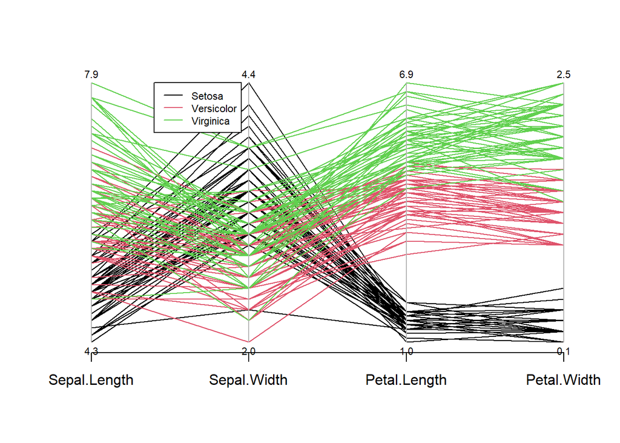

```r
library(MASS)
data(iris)
parcoord(iris[,c(1:4)],
         col = iris$Species,
         var.label = TRUE)
legend(1.4,1, legend = c("Setosa","Versicolor","Virginica"),
       lty=c(1,1,1),
       col=c(1:3),
       cex=0.7)
```

`MASS`패키지의 `parcoord`함수를 이용하여 평행좌표 그림을 나타내었다. - `parcoord(x,col,var.lable)`

- x: 데이터
- col: 선을 구분할 변수
- var.label: 축 변수들의 최대값, 최소값 출력 여부

**평행좌표 그래프**는 데이터의 각 행에 대한 값을 선 하나로 나타낸 그림으로, 다변량의 자료를 파악하기에 좋은 방법이다.

**iris**데이터의 평행좌표 그래프를 살펴본 결과, **Petal.Length, Petal.Width** 변수는 `Setosa`일 때, 대부분 작은 값을 가지고 `Virginica`일 때 대부분 큰 값을 가지는 것을 확인할 수 있다.

## Appendix: Chapter1

### Regression vs Correlation

**회귀분석(Regression)**은 인과관계를 맺고 있는 변수 간에 함수관계를 규명하여 통계적인 분석을 실행하는 방법을 말한다.  
상관분석과 달리 두 변수만이 아닌 둘 이상의 변수들의 관계를 파악할 수 있다.

**상관분석(Correlation)**은 두 변수간에 어떠한 선형적인 관계를 갖고있으며, 얼마나 밀접한 관계를 맺고 있는지 확인하는 방법이다.  
상관분석을 한 후에 도출된 상관계수는 -1부터 1의 값을 가지며, -1에 가까울수록 강한 음의 상관관계, 0에 가까우면 서로 관계가 없고 1에 가까울수록 양의 상관관계를 갖고 있다고 한다.

회귀분석과 상관분석의 가장 큰 차이점 중 하나는 구체적인 함수관계라고 할 수 있다.  
상관분석은 단순히 두 변수가 갖고있는 선형적 관계를 통해 함께 움직이는 정도만을 확인할 수 있다.  
하지만, 회귀분석은 상관분석과 달리 두 변수간의 함수관계를 규명함으로써 한 변수(독립변수)의 변화에 따라 한 변수(종속변수)에 얼마만큼의 영향을 미칠 수 있는지 확인할 수 있다.

## Chapter1 Summary

- 통계에서 데이터 분석을 진행함에 있어, 일반적으로 양적 변수와 질적 변수를 고려할 수 있다. **질적 변수(범주형 변수)**를 다루는 것은 **양적 변수**보다는 약간의 어려움이 따르기 때문에 질적 변수를 다룰 수 있는 능력을 키우는 것은 중요하다.
- **범주형 변수**는 변수들의 수준의 순서를 고려하지 않는 **명목형 변수**와 변수들의 수준의 순서를 고려하는 **순서형 변수**로 나눌 수 있다.
- 데이터 분석가의 분석 결과를 보고서의 형태로 정리할 때에는 데이터, 분석비법, 모델등을 정리하는 것도 중요하지만 보고받는 사람이 쉽게 이해할 수 있게 적절한 시각화를 통해 나타내는 것도 매우 중요한 요소이다.

# Chap2 Working with Categorical Data

범주형 변수를 다루기 위해서는 양적 변수를 다루는 기술 이상의 능력이 필요하다.  
**양적 변수**의 경우 숫자로 표현돼있기에 이상치, 데이터의 분포를 제외하고는 특별한 전처리 과정이 필요하지 않다.

하지만, **범주형 변수**의 경우 문자로 표현되는 데이터도 많기 때문에 이에 대한 전처리 과정 및 데이터의 **수준(level)의 순서**를 고려해야 될수도 있으며 특히, R에서는 범주형 변수의 저장 형태가 table의 형태로 이뤄지는 경우가 많기 때문에 이 부분 또한 고려해야 하는 요소이다.

Chapter2에서는 범주형 변수 데이터들의 주요 특성에 대해서 알아본다.

## 2.1 Working with R data: vectors, matrics, arrays, and dataframes

### 2.1.1 Vectors

- R에서 벡터(Vector)는 숫자, 문자, 또는 논리 같은 값을 가지는 것을 말하며, 종종 일부 분석에서 변수에 해당되기도 한다.
- 가장 단순한 데이터 구조이며, 동일한 요소의 1차원 집합이다.
- `c()`함수를 이용하여 인수를 결합한 벡터를 만들 수 있다.

```r
c(17, 20, 15, 40)
```

```
## [1] 17 20 15 40
```

```r
c("female", "male", "female", "male")
```

```
## [1] "female" "male"   "female" "male"
```

```r
c(TRUE, TRUE, FALSE, FALSE)
```

```
## [1]  TRUE  TRUE FALSE FALSE
```

R의 기본 내장함수 `c`를 이용하여 동일한 요소를 가지고 있는 1차원 벡터를 만들 수 있다.

```r
count  <- c(17, 20, 15, 40)
count
```

```
## [1] 17 20 15 40
```

만들어진 벡터를 `<-` 혹은 `=`을 통해 특정 객체에 저장할 수도 있다.

```r
(sex <- c("female", "male", "female", "male"))
```

```
## [1] "female" "male"   "female" "male"
```

```r
(passed <- c(TRUE, TRUE, FALSE, FALSE))
```

```
## [1]  TRUE  TRUE FALSE FALSE
```

객체 저장 후 바로 저장된 값을 출력하고 싶다면, 맨 앞과 맨 뒤에 *괄호()*를 입력하면 된다.

```r
seq(10, 100, by = 10)
```

```
##  [1]  10  20  30  40  50  60  70  80  90 100
```

```r
seq(0, 1, length.out = 11)
```

```
##  [1] 0.0 0.1 0.2 0.3 0.4 0.5 0.6 0.7 0.8 0.9 1.0
```

```r
seq(10,100,length.out = 10)
```

```
##  [1]  10  20  30  40  50  60  70  80  90 100
```

`seq`함수는 분석자가 정한 특정 범위와 간격을 기준으로 양적 데이터를 생성해주는 함수이다. - `seq(from, to, by | length.out)`

- from: 분석자가 원하는 범위의 초기값
- to: 분석자가 원하는 범위의 마지막값
- by: 초기값부터 마지막값까지의 간격
- length.out: 초기값부터 마지막값까지 몇 개를 출력하고자 하는지에 대한 옵션. 즉, 간격이 (from - to) / (length.out-1)이 된다.

`by`와 `length.out`은 혼합해서 사용할 수 없으며, 둘 중 하나의 옵션만을 사용해야 한다.

```r
(number <- rep(c(1,2,3,4,5),times = 2))
```

```
##  [1] 1 2 3 4 5 1 2 3 4 5
```

```r
(sex <- rep(c("female","male"),times=2))
```

```
## [1] "female" "male"   "female" "male"
```

```r
(sex <- rep(c("female","male"), length.out = 4))
```

```
## [1] "female" "male"   "female" "male"
```

```r
(passed <- rep(c(TRUE, FALSE), each = 2))
```

```
## [1]  TRUE  TRUE FALSE FALSE
```

`rep`함수는 입력한 값들을 원하는 만큼 반복한 데이터를 만들어주는 함수이다. - `rep(data,times | length.out | each)`

- data: 반복하고자 하는 데이터 (숫자는 물론 문자형도 가능하다.)
- times: 반복횟수
- length.out: 총 갯수 (지정한 만큼의 숫자까지 반복한다.)
- each: 각 데이터의 반복횟수 (times처럼 pair 형식으로 반복하는 것이 아니라 각각의 입력값들을 each만큼 반복한 후 다음 입력값을 반복해준다.)

### 2.1.2 Matrics

- **행렬(Matrics)**은 열 또는 행의 벡터로 구성된 전통적인 표와 같은 직사각형 배열이다.
- 일반적으로 선형대수학, 공분산행렬, 다변량 정규분포 등의 계산식을 활용하고자 할때 많이 쓰인다.

```r
(matA <- matrix(1:8, nrow=2, ncol = 4))
```

```
##      [,1] [,2] [,3] [,4]
## [1,]    1    3    5    7
## [2,]    2    4    6    8
```

```r
(matB <- matrix(1:8, nrow = 2, ncol = 4, byrow=TRUE))
```

```
##      [,1] [,2] [,3] [,4]
## [1,]    1    2    3    4
## [2,]    5    6    7    8
```

```r
(matC <- matrix(1:4, nrow = 2, ncol = 4))
```

```
##      [,1] [,2] [,3] [,4]
## [1,]    1    3    1    3
## [2,]    2    4    2    4
```

R 에서는 `matrix`함수를 이용하여 행렬을 만들 수 있다.  
- `matrix(data,nrow,col,byrow)` * data: 입력 값 * nrow: 행의 개수 * ncol: 열의 개수 * byrow: 입력값을 행을 우선으로 채울이 열로 채울지 결정. (**default는 False**이며, **TRUE**로 지정하게 되면 입력값을 행을 우선으로 채운다.)

```r
dim(matA)
```

```
## [1] 2 4
```

```r
str(matA)
```

```
##  int [1:2, 1:4] 1 2 3 4 5 6 7 8
```

`dim`은 만들어진 행렬 또는 데이터 프레임의 차원을 볼 수 있다. (2 4)가 의미하는 것은 2x4 즉, (2행 4열)을 의미한다.  
- `dim(data)`

- data: 행렬 또는 데이터 프레임

`str`은 만들어진 행렬 또는 데이터프레임의 데이터 타입, 크기, 입력값들을 볼 수 있다.  
- `str(data)`

- data: 행렬 또는 데이터 프레임

```r
dimnames(matA) <- list(c("M","F"), LETTERS[1:4])
matA
```

```
##   A B C D
## M 1 3 5 7
## F 2 4 6 8
```

```r
str(matA)
```

```
##  int [1:2, 1:4] 1 2 3 4 5 6 7 8
##  - attr(*, "dimnames")=List of 2
##   ..$ : chr [1:2] "M" "F"
##   ..$ : chr [1:4] "A" "B" "C" "D"
```

```r
dimnames(matA) <- list(sex = c("M","F"), group = LETTERS[1:4])
matA
```

```
##    group
## sex A B C D
##   M 1 3 5 7
##   F 2 4 6 8
```

```r
str(matA)
```

```
##  int [1:2, 1:4] 1 2 3 4 5 6 7 8
##  - attr(*, "dimnames")=List of 2
##   ..$ sex  : chr [1:2] "M" "F"
##   ..$ group: chr [1:4] "A" "B" "C" "D"
```

`dimnames`를 이용하여 행렬의 행의 이름, 열의 이름을 지정해줄수도 있다.  
- `dimnames(data) <- list(create_row = (row), create_col = (columns)`

- data: 행렬이 저장된 객체명
- create_row: 분석자가 지정하고자 하는 행의 이름
- row: 지정한 행 이름의 수준
- create_col: 분석자가 지정하고자 하는 열의 이름
- col: 지정한 열 이름의 수준

```r
rbind(matA, c(10,20))
```

```
##    A  B  C  D
## M  1  3  5  7
## F  2  4  6  8
##   10 20 10 20
```

```r
cbind(matA, c(10,20))
```

```
##   A B C D
## M 1 3 5 7 10
## F 2 4 6 8 20
```

`rbind`함수는 가지고 있는 행렬 또는 데이터 프레임의 행을 기준으로 데이터를 추가해준다.

`cbind`함수는 반대로 열을 기준으로 데이터를 추가해준다.

특히, 두 함수 모두 추가하고자 하는 데이터가 행 또는 열보다 작은 경우, R이 자동적으로 데이터를 반복하여 추가해주는 것을 알 수 있다.

- `rbind | cbind (data, append)`
- data: 행렬 또는 데이터 프레임이 저장된 객체
- append: 추가하고자 하는 데이터

```r
t(matA)
```

```
##      sex
## group M F
##     A 1 2
##     B 3 4
##     C 5 6
##     D 7 8
```

`t`함수는 행렬의 `전치(transpose)`를 만들어주는 역할을 한다.

- `t(data)`
- data: 행렬이 저장된 객체

```r
2 * matA / 100
```

```
##    group
## sex    A    B    C    D
##   M 0.02 0.06 0.10 0.14
##   F 0.04 0.08 0.12 0.16
```

만들어진 행렬 객체에 수식을 입력하여 전체 행렬에 대한 연산을 진행할수도 있다.

### 2.1.3 Arrays

- **배열(Arrays)**은 행,열,계층으로 구성된 3원 테이블로 표현될 수 있도록 추가 차원을 추가한다.
- 중요한 것은 벡터, 행렬, 배열의 값이 모두 동일한 형태를 가지고 있어야 한다.
- 고차원 배열은 전통적인 데이터분석에서 빈번하게 쓰이진 않지만, 3개 이상의 변수의 빈도표가 테이블 변수에 대해 하나의 차원의 배열로 표현될 수 있는 범주형 데이터에 유용하다.

```r
dims <- c(2, 4, 2)
(arrayA <- array(1:16, dim = dims))
```

```
## , , 1
##
##      [,1] [,2] [,3] [,4]
## [1,]    1    3    5    7
## [2,]    2    4    6    8
##
## , , 2
##
##      [,1] [,2] [,3] [,4]
## [1,]    9   11   13   15
## [2,]   10   12   14   16
```

```r
str(arrayA)
```

```
##  int [1:2, 1:4, 1:2] 1 2 3 4 5 6 7 8 9 10 ...
```

`array`는 R에서 배열을 만들어주는 함수이다.

- `array(data,dim)`
- data: 배열을 통해 표현하고자 하는 데이터
- dim: 사용자가 지정하고자 하는 차원의 크기(행,열,계층)

앞에서 설명했듯이, 행렬과 다르게 배열은 **계층**이라는 구조를 추가적으로 가진다.  
`str`을 통해서 배열이 갖고 있는 정보와 크기를 확인할 수 있는데 위 배열(array)의 경우, 2rows, 4columns, 2layers(계층)을 가지는 배열(array)이다.

```r
(arrayB <- array(1:16, dim = c(2,8)))
```

```
##      [,1] [,2] [,3] [,4] [,5] [,6] [,7] [,8]
## [1,]    1    3    5    7    9   11   13   15
## [2,]    2    4    6    8   10   12   14   16
```

```r
str(arrayB)
```

```
##  int [1:2, 1:8] 1 2 3 4 5 6 7 8 9 10 ...
```

`array`함수에서 `dim`옵션을 사용할때, 레이어를 별도로 지정해주지 않으면 mxn의 크기를 갖는 행렬과 같게 표현될 수 있다.  
`str`을 통해 차원이 2rows, 8columns을 갖는 것을 확인할 수 있다.

```r
dimnames(arrayA) <- list(sex = c("M", "F"),
                         group = letters[1:4],
                         time = c("Pre", "Post"))
arrayA
```

```
## , , time = Pre
##
##    group
## sex a b c d
##   M 1 3 5 7
##   F 2 4 6 8
##
## , , time = Post
##
##    group
## sex  a  b  c  d
##   M  9 11 13 15
##   F 10 12 14 16
```

```r
str(arrayA)
```

```
##  int [1:2, 1:4, 1:2] 1 2 3 4 5 6 7 8 9 10 ...
##  - attr(*, "dimnames")=List of 3
##   ..$ sex  : chr [1:2] "M" "F"
##   ..$ group: chr [1:4] "a" "b" "c" "d"
##   ..$ time : chr [1:2] "Pre" "Post"
```

배열(array) 또한 행렬과 같이 `dimnames`함수를 이용하여 행,열,계층마다 이름을 만들고 그에 따른 수준을 지정하는것이 가능한 것을 확인할 수 있다.

### 2.1.4 Data frames

- **데이터프레임(Dataframe)**은 R에서 가장 일반적으로 사용되는 데이터 형식이다.
- 특히, 데이터를 분석하고자 할 때, 굉장히 유용하게 사용할 수 있다.
- 다른 통계 환경의 전통적인 데이터 세트처럼 직사각형 테이블이며 행과 열로 구성되지만 다른 유형의 변수를 추가할 수 있다.
- 데이터 프레임은 기본적으로 각각 데이터 프레임의 열을 나타내는 동일한 크기의 벡터 리스트이다.

```r
set.seed(12345)
n <- 100
A <- factor(sample(c("a1","a2"),n, replace = TRUE))
B <- factor(sample(c("b1","b2"),n, replace = TRUE))
sex <- factor(sample(c("M","F"),n, replace = TRUE))
age <- round(rnorm(n, mean = 30, sd = 5))
mydata <- data.frame(A, B, sex, age)
head(mydata,5)
```

```
##    A  B sex age
## 1 a2 b1   F  22
## 2 a1 b1   M  33
## 3 a2 b1   F  31
## 4 a2 b2   M  26
## 5 a2 b1   M  29
```

R에서 데이터프레임은 `data.frame`이라는 함수를 통해 생성할 수 있다. 단, 데이터프레임으로 만들 때 모든 변수들의 크기는 반드시 같아야 한다.

`data.frame(data)`

- data: 데이터프레임으로 바꾸어줄 변수들(하나 혹은 다중도 가능)

다양한 유형의 변수들을 **mydata**라는 객체에 데이터 프레임 형태로 한번에 저장할 수 있다.

```r
str(mydata)
```

```
## 'data.frame':    100 obs. of  4 variables:
##  $ A  : Factor w/ 2 levels "a1","a2": 2 1 2 2 2 2 2 1 1 2 ...
##  $ B  : Factor w/ 2 levels "b1","b2": 1 1 1 2 1 1 1 1 2 1 ...
##  $ sex: Factor w/ 2 levels "F","M": 1 2 1 2 2 2 2 1 2 2 ...
##  $ age: num  22 33 31 26 29 29 38 28 30 27 ...
```

`str`함수를 통해 데이터 프레임의 각 변수에 대한 데이터 타입과 전반적인 데이터 프레임의 크기를 확인할 수 있다.  
위 데이터의 경우 100개의 관측값과 4개의 변수를 가지는 데이터 프레임인 것을 알 수 있다.

```r
mydata[1,2]
```

```
## [1] b1
## Levels: b1 b2
```

데이터프레임에서 `저장한 객체명`과 `[]`을 활용하면 원하는 값을 쉽게 인덱싱 할 수 있다.  
위의 코드는 mydata에서 1행 2열에 위치한 값을 출력해달라는 의미이다.

```r
mydata[,1]
```

```
##   [1] a2 a1 a2 a2 a2 a2 a2 a1 a1 a2 a2 a2 a2 a1 a2 a1 a2 a2 a1 a2 a2 a1 a2 a2 a1
##  [26] a2 a2 a2 a2 a2 a1 a1 a2 a1 a2 a2 a2 a1 a2 a2 a2 a2 a2 a2 a1 a2 a1 a2 a1 a2
##  [51] a2 a1 a2 a1 a1 a1 a1 a1 a1 a1 a1 a2 a2 a1 a1 a1 a1 a1 a1 a2 a2 a1 a1 a2 a1
##  [76] a2 a2 a2 a1 a1 a2 a1 a1 a2 a1 a1 a1 a2 a1 a1 a1 a1 a2 a1 a2 a2 a2 a1 a2 a2
## Levels: a1 a2
```

`mydata[,1]`은 mydata의 1열에 있는 모든 값을 출력하라는 의미다. 즉 mydata에서 1열은 A라는 변수이므로 A변수의 데이터가 모두 출력되는 것을 확인할 수 있다.

```r
mydata[1,]
```

```
##    A  B sex age
## 1 a2 b1   F  22
```

`mydata[1,]`는 mydata의 1행에 있는 모든 값을 출력하라는 의미로, 변수 A,B,sex,age의 각 첫번째 값이 출력된 것을 확인할 수 있다.  
이는 첫번째 관측치의 모든 데이터를 의미한다.

```r
mydata$sex
```

```
##   [1] F M F M M M M F M M M M M M M M M F F M M M F F F M F M M M F M F F F F F
##  [38] M M M F F F M F M M M F F M F F M F M M F F F F F M F M M M M M F M M M M
##  [75] F M F F F M M F M F F F F F M M F M M M F F F F M F
## Levels: F M
```

또한, R에서 `데이터 프레임 객체명$변수`를 하게 되면 지정한 변수의 값만 확인할 수 있다.

*Example 2.1: Arthritis treatment*

```r
write.table(Arthritis, file = "Arthritis.csv", quote = FALSE, sep = ",")
path <- "Arthritis.csv"

Arthritis <- read.table(path, header = TRUE, sep = ",")
```

`read.table`을 이용하여 table format으로 돼있는 데이터를 읽어올 수 있다.

- `read.table(file, header, sep)`
- file: 읽어오고자 하는 파일의 위치
- header: 데이터의 첫 번째 행을 포함시킬지 유무
- sep: 데이터를 어떠한 형식에 따라 분리할 것인지

```r
head(Arthritis)
```

```
##   ID Treatment  Sex Age Improved
## 1 57   Treated Male  27     Some
## 2 46   Treated Male  29     None
## 3 77   Treated Male  30     None
## 4 17   Treated Male  32   Marked
## 5 36   Treated Male  46   Marked
## 6 23   Treated Male  58   Marked
```

```r
str(Arthritis)
```

```
## 'data.frame':    84 obs. of  5 variables:
##  $ ID       : int  57 46 77 17 36 23 75 39 33 55 ...
##  $ Treatment: chr  "Treated" "Treated" "Treated" "Treated" ...
##  $ Sex      : chr  "Male" "Male" "Male" "Male" ...
##  $ Age      : int  27 29 30 32 46 58 59 59 63 63 ...
##  $ Improved : chr  "Some" "None" "None" "Marked" ...
```

```r
Arthritis$Improved <- as.factor(Arthritis$Improved)
levels(Arthritis$Improved)
```

```
## [1] "Marked" "None"   "Some"
```

R에서 **factor**데이터는 범주형 데이터를 일컫는다.  
`levels(수준)`를 통해 **facotr**데이터가 갖고 있는 범주형 데이터의 수준을 확인할 수 있다.

`Arthritis`의 `Imrpoved`변수의 경우, **(약의 효과가) 뚜렷함, 없음, 약간**의 순서대로 수준을 갖고있는 것을 확인할 수 있다.

```r
Arthritis$Improved <- ordered(Arthritis$Improved,
                              levels = c("None","Some","Marked"))
levels(Arthritis$Improved)
```

```
## [1] "None"   "Some"   "Marked"
```

**factor**데이터의 순서를 의미있게 지정해주고 싶다면, `ordered`함수를 이용하여 범주형 데이터의 순서를 지정해줄 수 있다.

- `ordered(data, levels)`
- data: 수준의 순서를 바꾸고자 하는 데이터
- levles: 수준의 순서를 재지정하고 싶은대로 수준을 재지정한다.

위의 코드는 약의 효과에 대한 수준의 순서를 **없음, 약간, 뚜렷함**의 순서로 수준의 순서를 재지정하는 코드이다.

## 2.2 Forms of categorical data: case form, frequency form, and table form

### 2.2.1 Case form

범주형 데이터는 단순히 데이터 프레임으로, 하나 이상의 이산형 분류변수 또는 반응변수가 있으며, 편리하게 요인 또는 순서요인으로 표현된다.  
**Case form**은 데이터를 케이스 형태로 표현한 것을 말한다.  
예를 들어, 각 환자에 대한 고유 ID, 그 환자의 정보, 약 효과 등 사례를 중심으로 나타낸 데이터는 **Case form**데이터 라고 할 수 있다.

*Example 2.2: Arthritis treatment*

```r
data("Arthritis", package = "vcd")
head(Arthritis,5)
```

```
##   ID Treatment  Sex Age Improved
## 1 57   Treated Male  27     Some
## 2 46   Treated Male  29     None
## 3 77   Treated Male  30     None
## 4 17   Treated Male  32   Marked
## 5 36   Treated Male  46   Marked
```

`Arthritis`데이터의 경우 각 환자의 ID, 치료 방법, 성별, 나이, 결과 등 실험에 대한 사례가 나와있다.  
따라서, 데이터를 케이스의 형태로 표현했기 때문에 **Case form**에 속한다고 할 수 있다.

### 2.2.2 Frequency form

**빈도 형식(Frequency form)**은 하나 이상의 이산 요인 변수와 해당 셀의 기본 관측치 수를 나타내는 빈도 변수를 포함하는 형태이다.

*Example 2.3: General social survey*

```r
tmp <- expand.grid(sex = c("female","male"),
                   party = c("dem", "indep","rep"))
tmp
```

```
##      sex party
## 1 female   dem
## 2   male   dem
## 3 female indep
## 4   male indep
## 5 female   rep
## 6   male   rep
```

`expand.grid`는 제공되는 범주형 변수의 모든 조합을 사용하여 데이터를 만들 수 있는 함수이다.

- `expand.grid(data)`
- data: 조합하고자 하는 범주형 변수

위의 코드의 경우, 2개의 범주형 변수가 각각 2,3개의 수준을 가지므로 총 6개의 범주형 조합이 만들어지는 것을 확인할 수 있다.

```r
GSS <- data.frame(tmp, count = c(279, 165, 73, 47, 227, 191))
GSS
```

```
##      sex party count
## 1 female   dem   279
## 2   male   dem   165
## 3 female indep    73
## 4   male indep    47
## 5 female   rep   227
## 6   male   rep   191
```

`expand.grid`를 통해 만들어진 모든 범주형 조합에 빈도를 추가한 후, `data.frame`함수를 통해 데이터 프레임의 형태로 만들어주었다.

```r
names(GSS)
```

```
## [1] "sex"   "party" "count"
```

```r
str(GSS)
```

```
## 'data.frame':    6 obs. of  3 variables:
##  $ sex  : Factor w/ 2 levels "female","male": 1 2 1 2 1 2
##  $ party: Factor w/ 3 levels "dem","indep",..: 1 1 2 2 3 3
##  $ count: num  279 165 73 47 227 191
```

이처럼 변수들과 그에 대한 기본 관측치를 갖고 있는 형식을 **빈도 형식**이라고 한다.

```r
sum(GSS$count)
```

```
## [1] 982
```

빈도 형태를 가지는 데이터의 경우, `sum`을 통해 전체 빈도를 계산할 수 있다.

```r
apply(GSS,2,function(x) max(x))
```

```
##    sex  party  count
## "male"  "rep"  "279"
```

`apply`함수의 경우 데이터프레임에 함수을 적용함에 있어 상당히 유용하게 적용할 수 있게 해주는 함수이다.

- `apply(data,margin,fun)`
- data: 분석자가 분석을 하고자하는 데이터
- margin: 행을 기준으로 할 것인지 열을 기준으로 할 것인지(1 = 행, 2 = 열)
- fun: margin을 통해 나눠진 데이터에 적용할 함수(일반적으로 function(x) 원하는 함수(x)의 형태로 사용한다. 여기서, x = 나눠진 데이터)

### 2.2.3 Table form

**테이블 형태(Table form)**의 데이터는 매트릭스, 배열 혹은 테이블 객체로 표현된다.  
표의 차원은 테이블의 길이, 표의 크기는 속성들의 길이를 나타낸다.

*Example 2.4: Hair color and eye color*

```r
data("HairEyeColor", package = "datasets")
HairEyeColor
```

```
## , , Sex = Male
##
##        Eye
## Hair    Brown Blue Hazel Green
##   Black    32   11    10     3
##   Brown    53   50    25    15
##   Red      10   10     7     7
##   Blond     3   30     5     8
##
## , , Sex = Female
##
##        Eye
## Hair    Brown Blue Hazel Green
##   Black    36    9     5     2
##   Brown    66   34    29    14
##   Red      16    7     7     7
##   Blond     4   64     5     8
```

**HairEyeColor**는 위와 같이 테이블 객체로 표현되기 때문에 **Table form**에 속하는 것을 확인할 수 있다.

```r
dim(HairEyeColor)
```

```
## [1] 4 4 2
```

```r
dimnames(HairEyeColor)
```

```
## $Hair
## [1] "Black" "Brown" "Red"   "Blond"
##
## $Eye
## [1] "Brown" "Blue"  "Hazel" "Green"
##
## $Sex
## [1] "Male"   "Female"
```

```r
sum(HairEyeColor)
```

```
## [1] 592
```

`dim`함수를 통해 데이터의 크기를 본 결과, 각 속성들은 4행 4열의 길이를 가지고 2개의 테이블을 가지고 있는 데이터임을 확인할 수 있다.  
또한, `dimnames`함수를 통해 속성들의 요인을 확인할 수 있으며, `sum`을 통해 셀의 전체 빈도의 합을 구할 수 있다.

*Example 2.5: Job satisfaction*

```r
JobSat <- matrix(c(1,2,1,0,
                   3,3,6,1,
                   10,10,14,9,
                   6,7,12,11),
                   nrow = 4, ncol = 4)

str(JobSat)
```

```
##  num [1:4, 1:4] 1 2 1 0 3 3 6 1 10 10 ...
```

```r
dimnames(JobSat) <-
  list(income = c("< 15k", "15-25k", "25-40k", "> 40k"),
       satisfaction = c("VeryD", "LittleD", "ModerateS", "VeryS"))

JobSat <- as.table(JobSat)
JobSat
```

```
##         satisfaction
## income   VeryD LittleD ModerateS VeryS
##   < 15k      1       3        10     6
##   15-25k     2       3        10     7
##   25-40k     1       6        14    12
##   > 40k      0       1         9    11
```

```r
str(JobSat)
```

```
##  'table' num [1:4, 1:4] 1 2 1 0 3 3 6 1 10 10 ...
##  - attr(*, "dimnames")=List of 2
##   ..$ income      : chr [1:4] "< 15k" "15-25k" "25-40k" "> 40k"
##   ..$ satisfaction: chr [1:4] "VeryD" "LittleD" "ModerateS" "VeryS"
```

`as.table`의 경우 원하는 데이터를 테이블의 형태로 바꿔주는 함수이다.

- `as.table(data)`
- data: table의 형태로 바꾸고자 하는 데이터

`as.table`을 통해 매트릭스의 형태인 데이터를 테이블의 형태로 쉽게 바꿀 수 있는 것을 확인할 수 있다.

## 2.3 Ordered factors and reordered tables

```r
dimnames(JobSat)$income <- c(7.5, 20, 32.5, 60)
dimnames(JobSat)$satisfaction <- 1:4
JobSat
```

```
##       satisfaction
## income  1  2  3  4
##   7.5   1  3 10  6
##   20    2  3 10  7
##   32.5  1  6 14 12
##   60    0  1  9 11
```

만들어진 데이터의 범주형 변수의 수준을 `$`를 통해 재지정할 수 있다.

```r
dimnames(JobSat)$income <-
  paste(1:4, dimnames(JobSat)$income, sep = ":")

dimnames(JobSat)$satisfaction <-
  paste(1:4, dimnames(JobSat)$satisfaction, sep = ":")
JobSat
```

```
##         satisfaction
## income   1:1 2:2 3:3 4:4
##   1:7.5    1   3  10   6
##   2:20     2   3  10   7
##   3:32.5   1   6  14  12
##   4:60     0   1   9  11
```

범주형 변수의 순서를 확인하기 위해 기존에 존재하던 범주형 변수 이름 앞에 순서를 부여하여 순서를 쉽게 확인할 수도 있다.

```r
data("HairEyeColor", package = "datasets")
HEC <- HairEyeColor[, c(1, 3, 4, 2),]
str(HEC)
```

```
##  'table' num [1:4, 1:4, 1:2] 32 53 10 3 10 25 7 5 3 15 ...
##  - attr(*, "dimnames")=List of 3
##   ..$ Hair: chr [1:4] "Black" "Brown" "Red" "Blond"
##   ..$ Eye : chr [1:4] "Brown" "Hazel" "Green" "Blue"
##   ..$ Sex : chr [1:2] "Male" "Female"
```

```r
HEC
```

```
## , , Sex = Male
##
##        Eye
## Hair    Brown Hazel Green Blue
##   Black    32    10     3   11
##   Brown    53    25    15   50
##   Red      10     7     7   10
##   Blond     3     5     8   30
##
## , , Sex = Female
##
##        Eye
## Hair    Brown Hazel Green Blue
##   Black    36     5     2    9
##   Brown    66    29    14   34
##   Red      16     7     7    7
##   Blond     4     5     8   64
```

기존에 존재하던 범주형 변수의 순서를 다르게 하고 싶다면 `[]`을 통해 인덱싱을 활용하여 바꿀수도 있다.  
Eye변수의 수준의 순서를 **Brown,Blue,Hazel,Green**에서 인덱싱을 통해 **Brown,Hazel,Green,Blue**로 바꿔주었다.

```r
str(UCBAdmissions)
```

```
##  'table' num [1:2, 1:2, 1:6] 512 313 89 19 353 207 17 8 120 205 ...
##  - attr(*, "dimnames")=List of 3
##   ..$ Admit : chr [1:2] "Admitted" "Rejected"
##   ..$ Gender: chr [1:2] "Male" "Female"
##   ..$ Dept  : chr [1:6] "A" "B" "C" "D" ...
```

**UCBAdmissions** 데이터는 UC Berkeley의 학생 입학 정보를 나타내고 있는 데이터이다.

`str`함수를 이용하여 *UCBAdmissions* 데이터의 정보를 파악하였다. 3개의 변수를 갖고있는 테이블 형식의 변수임을 확인할 수 있다.

- Admit: 입학 승인 여부 (Factor variable - Admitted, Rejected)
- Gender: 성별 (Factor variable - Male, Female)
- Dept: 지원 부서 (Factor variable - A,B,C,D,E,F)

```r
UCB <- aperm(UCBAdmissions, c(2,1,3))
dimnames(UCB)$Admit <- c("YES", "NO")
names(dimnames(UCB)) <- c("Sex", "Admitted", "Department")

str(UCB)
```

```
##  'table' num [1:2, 1:2, 1:6] 512 89 313 19 353 17 207 8 120 202 ...
##  - attr(*, "dimnames")=List of 3
##   ..$ Sex       : chr [1:2] "Male" "Female"
##   ..$ Admitted  : chr [1:2] "YES" "NO"
##   ..$ Department: chr [1:6] "A" "B" "C" "D" ...
```

```r
UCB
```

```
## , , Department = A
##
##         Admitted
## Sex      YES  NO
##   Male   512 313
##   Female  89  19
##
## , , Department = B
##
##         Admitted
## Sex      YES  NO
##   Male   353 207
##   Female  17   8
##
## , , Department = C
##
##         Admitted
## Sex      YES  NO
##   Male   120 205
##   Female 202 391
##
## , , Department = D
##
##         Admitted
## Sex      YES  NO
##   Male   138 279
##   Female 131 244
##
## , , Department = E
##
##         Admitted
## Sex      YES  NO
##   Male    53 138
##   Female  94 299
##
## , , Department = F
##
##         Admitted
## Sex      YES  NO
##   Male    22 351
##   Female  24 317
```

`aperm`함수는 차원을 재배열해주는 함수이다.

- `aperm(data, order)`
- data: 차원을 재배열하고자 하는 데이터
- order: 차원을 재배열하고자 하는 순서

테이블에 `aperm`함수를 지정해주게 되면 테이블을 구성하는 셀 변수의 위치를 바꿀 수 있다.  
`dimnames, names`를 통해 셀을 구성하는 변수의 범주 이름도 변경이 가능하다.

## 2.4 Generating tables with table() and xtabs()

```r
set.seed(1234)
n <- 100
A <- factor(sample(c("a1","a2"), n, replace = TRUE))
B <- factor(sample(c("b1","b2"), n, replace = TRUE))
sex<- factor(sample(c("M","F"), n, replace = TRUE))
age <- round(rnorm(n, mean = 30, sd = 5))
mydata <- data.frame(A, B, sex, age)
head(mydata,5)
```

```
##    A  B sex age
## 1 a2 b2   F  28
## 2 a2 b1   M  30
## 3 a2 b1   F  38
## 4 a2 b1   M  26
## 5 a1 b1   M  31
```

앞서 만든 `mydata`를 난수고정을 변경하여 다시 한 번 만들어주었다.

### 2.4.1 table()

```r
table(mydata$A, mydata$B)
```

```
##
##      b1 b2
##   a1 23 19
##   a2 25 33
```

데이터 프레임 객체에 `table`함수를 지정하게 되면 지정한 변수간의 빈도로 테이블을 구성해준다.

- `table(data1,data2...)`
- data1,data2…: `table`로 구성하고자 하는 원하는 데이터를 넣어준다.

```r
(mytab <- table(mydata[,1:2]))
```

```
##     B
## A    b1 b2
##   a1 23 19
##   a2 25 33
```

`$`가 아닌 인덱싱을 통해서도 `table`함수를 적용할 수 있으며, 인덱싱을 이용하여 적용하면 범주형 변수의 이름까지 출력되는 것을 확인할 수 있다.

```r
margin.table(mytab)
```

```
## [1] 100
```

```r
margin.table(mytab, 1)
```

```
## A
## a1 a2
## 42 58
```

```r
margin.table(mytab, 2)
```

```
## B
## b1 b2
## 48 52
```

`margin.table`함수를 이용하면 테이블 내에서의 합을 쉽게 구할 수 있다.

- `margin.table(data,margin)
- data: 테이블 내에 합을 구할 데이터
- margin: 연산의 기준 (1 = 행, 2 = 열, NULL = 전체)

```r
addmargins(mytab)
```

```
##      B
## A      b1  b2 Sum
##   a1   23  19  42
##   a2   25  33  58
##   Sum  48  52 100
```

`addmargins`함수를 이용하면 셀의 행, 열에 따른 합 뿐만 아니라 테이블 전체 합을 한번에 확인할 수 있다.

- `addmargins(data)`
- data: 함수를 적용할 데이터

```r
prop.table(mytab)
```

```
##     B
## A      b1   b2
##   a1 0.23 0.19
##   a2 0.25 0.33
```

```r
prop.table(mytab,1)
```

```
##     B
## A           b1        b2
##   a1 0.5476190 0.4523810
##   a2 0.4310345 0.5689655
```

```r
prop.table(mytab,2)
```

```
##     B
## A           b1        b2
##   a1 0.4791667 0.3653846
##   a2 0.5208333 0.6346154
```

`prop.table`함수를 이용하면 테이블 내에서의 비율을 구할 수 있다.

- `prop.table(data,margin)`
- data: 테이블 내에 비율을 구할 데이터
- margin: 연산의 기준 (1 = 행, 2 = 열, NULL = 전체)

```r
mytab <- table(mydata[,c("A","B","sex")])
mytab
```

```
## , , sex = F
##
##     B
## A    b1 b2
##   a1 10 10
##   a2  9 16
##
## , , sex = M
##
##     B
## A    b1 b2
##   a1 13  9
##   a2 16 17
```

```r
ftable(mytab)
```

```
##       sex  F  M
## A  B
## a1 b1     10 13
##    b2     10  9
## a2 b1      9 16
##    b2     16 17
```

3차원의 테이블을 `table`함수를 이용해서 살펴보면 한 눈에 보기가 쉽지 않다.  
이때, `ftable`함수를 이용하면 `table`함수를 이용한 것 보다 3차원의 테이블을 한 눈에 쉽게 살펴볼 수 있다.

- `ftable(data)`
- data: 다차원의 분할표를 쉽게 보고자하는 데이터

### 2.4.2 xtabs()

```r
mytable <- xtabs(~ A + B + sex, data = mydata)
ftable(mytable)
```

```
##       sex  F  M
## A  B
## a1 b1     10 13
##    b2     10  9
## a2 b1      9 16
##    b2     16 17
```

`xtabs`함수는 데이터에 저장된 변수를 **Formula**를 사용하여 테이블을 구성할 수 있게 만들어주는 함수이다.

- `xtabs(formula, data)`
- formula: 분석가가 원하고자 하는 테이블의 형태로 구성할 수 있게 해주는 식
- data: formula를 적용할 데이터

위의 코드의 경우, ~ A + B + sex의 형태의 Formula이기 때문에 A가 행, B가 열, Sex가 계층을 이루는 `table`을 구성해준다.

```r
summary(mytable)
```

```
## Call: xtabs(formula = ~A + B + sex, data = mydata)
## Number of cases in table: 100
## Number of factors: 3
## Test for independence of all factors:
##  Chisq = 2.6519, df = 4, p-value = 0.6177
```

만들어진 테이블 데이터에 `summary()`를 하게되면, **table의 총 빈도, factor의 수, Chisq-test**까지 진행해준 결과를 보여준다.  
모든 factor에 대한 독립성 검정결과, 유의확률이 0.6177로 유의수준 0.05보다 크므로 귀무가설을 기각하지 못한다.  
따라서, 모든 요인들은 서로 독립인 것을 확인할 수 있다.

```r
(GSStab <- xtabs(count ~ sex + party, data = GSS))
```

```
##         party
## sex      dem indep rep
##   female 279    73 227
##   male   165    47 191
```

```r
summary(GSStab)
```

```
## Call: xtabs(formula = count ~ sex + party, data = GSS)
## Number of cases in table: 982
## Number of factors: 2
## Test for independence of all factors:
##  Chisq = 6.675, df = 2, p-value = 0.03553
```

`빈도 ~ 변수 + 변수`형태의 Formula로 지정하여 table을 구성할수도 있다.  
위의 코드의 경우, `count ~ sex + party`의 형태이므로, count에 따른 행(sex), 열(party)의 테이블이 구성된다.  
**chisq-test**결과, 유의확률이 0.03553으로 유의수준 0.05보다 작으므로 party와 sex 변수는 서로 연관성이 있으며 독립이 아닌 것을 알 수 있다.

## 2.5 Printing tables with structable() and ftable()

### 2.5.1 Text output

```r
ftable(UCB)
```

```
##                 Department   A   B   C   D   E   F
## Sex    Admitted
## Male   YES                 512 353 120 138  53  22
##        NO                  313 207 205 279 138 351
## Female YES                  89  17 202 131  94  24
##        NO                   19   8 391 244 299 317
```

**UCBAdmissions** 데이터의 경우 차원이 꽤 크게 구성 돼있는 데이터이다.  
이때, `ftable`을 적용하면 여러 차원에 있는 데이터를 한번에 쉽게 살펴볼 수 있다.

```r
ftable(Admitted + Sex ~ Department, data = UCB)
```

```
##            Admitted  YES          NO
##            Sex      Male Female Male Female
## Department
## A                    512     89  313     19
## B                    353     17  207      8
## C                    120    202  205    391
## D                    138    131  279    244
## E                     53     94  138    299
## F                     22     24  351    317
```

`ftable`또한 Formula를 이용하여 테이블을 연구자 본인이 원하는대로 구성할 수 있다.  
`Admitted + Sex ~ Department`는 합격유무와 성별 변수를 부서에 따라서 테이블을 구성하라는 Formula이다.

```r
library(vcd)
structable(HairEyeColor)
```

```
##              Eye Brown Blue Hazel Green
## Hair  Sex
## Black Male          32   11    10     3
##       Female        36    9     5     2
## Brown Male          53   50    25    15
##       Female        66   34    29    14
## Red   Male          10   10     7     7
##       Female        16    7     7     7
## Blond Male           3   30     5     8
##       Female         4   64     5     8
```

`structable`또한 R에서 제공하는 다차원의 분할표를 한 테이블안에 생성할 수 있게 만들어주는 함수이다.

- `structable(formula, data)`
- formula: 분석가가 원하고자 하는 테이블의 형태로 구성할 수 있게 해주는 식
- data: 테이블로 변환할 데이터 (formula가 없을 경우 기존 변수의 순서대로 테이블을 구성)

```r
structable(Hair + Sex ~ Eye, HairEyeColor)
```

```
##       Hair Black        Brown         Red        Blond
##       Sex   Male Female  Male Female Male Female  Male Female
## Eye
## Brown         32     36    53     66   10     16     3      4
## Blue          11      9    50     34   10      7    30     64
## Hazel         10      5    25     29    7      7     5      5
## Green          3      2    15     14    7      7     8      8
```

위의 코드는 Formula를 이용한 것으로, 머리색깔과 성별을 눈의 색깔에 따라 테이블을 구성하라는 의미이다.

## 2.6 Subsetting data

### 2.6.1 Subsetting tables

```r
HairEyeColor[,,"Female"]
```

```
##        Eye
## Hair    Brown Blue Hazel Green
##   Black    36    9     5     2
##   Brown    66   34    29    14
##   Red      16    7     7     7
##   Blond     4   64     5     8
```

다차원의 분할표로 구성된 테이블에서 `[,,"차원의 변수 중 원하는 범주]`로 지정하게 되면 차원을 구성하는 변수 중 원하는 범주만의 데이터를 볼 수 있다.

위의 코드는 `HairEyeColor`에서 `Female`의 Hair,Eye를 출력해달라는 코드이다.

```r
HairEyeColor[c("Black","Brown"), c("Hazel", "Green"),]
```

```
## , , Sex = Male
##
##        Eye
## Hair    Hazel Green
##   Black    10     3
##   Brown    25    15
##
## , , Sex = Female
##
##        Eye
## Hair    Hazel Green
##   Black     5     2
##   Brown    29    14
```

또는 위와같이 원하는 셀의 속성 중 원하는 범주형 변수만의 데이터만을 살펴볼수도 있다.  
위의 코드는 Hair는 `Black, Brown`, Eye는 `Hazel, Green`만을 출력하게 만드는 인덱싱이다.

```r
apply(HairEyeColor, 3, sum)
```

```
##   Male Female
##    279    313
```

`apply`함수를 이용하여 테이블을 구성하는 차원 변수에 따른 sum을 구하였다.  
앞에서 설명한 `apply`의 경우 margin이 1 또는 2만을 가졌지만, 테이블의 경우 특이하게 `margin = 3`까지 지정할 수 있다.  
`margin = 3`은 계층에 따라서 함수를 적용하라는 의미이다. 즉, `HairEyeColor`에서는 계층이 성별이므로 성별에 따른 합이 출력되는 것을 확인할 수 있다.

### 2.6.2 Subsetting structables

```r
hec <- structable(Eye ~ Sex + Hair, data = HairEyeColor)
hec
```

```
##              Eye Brown Blue Hazel Green
## Sex    Hair
## Male   Black        32   11    10     3
##        Brown        53   50    25    15
##        Red          10   10     7     7
##        Blond         3   30     5     8
## Female Black        36    9     5     2
##        Brown        66   34    29    14
##        Red          16    7     7     7
##        Blond         4   64     5     8
```

**hec**이라는 객체안에 **HairEyeColor**변수에 `structable`을 적용한(눈에 따른 성별과 머리의 빈도) 하나의 분할표로 이루어진 데이터를 저장하였다.

```r
hec["Male",]
```

```
##            Eye Brown Blue Hazel Green
## Sex  Hair
## Male Black        32   11    10     3
##      Brown        53   50    25    15
##      Red          10   10     7     7
##      Blond         3   30     5     8
```

위의 코드는 `[]`을 사용하여 남성의 Eye와 Hair만을 출력할 수 있게 인덱싱을 적용한 코드이다.

```r
hec[["Male",]]
```

```
##       Eye Brown Blue Hazel Green
## Hair
## Black        32   11    10     3
## Brown        53   50    25    15
## Red          10   10     7     7
## Blond         3   30     5     8
```

`[[]]`을 적용하여 인덱싱을 적욯하면 3차원인 성별에 대한 계층은 출력되지 않는 것을 확인할 수 있다.

```r
hec[[c("Male", "Brown"),]]
```

```
## Eye Brown Blue Hazel Green
##
##        53   50    25    15
```

`[[]]와 c()`를 결합시켜 남성 중 갈색 머리를 가진 사람들의 눈색깔만 출력할 수 있게 인덱싱을 적용한 결과이다.

### 2.6.3 Subsetting data frames

```r
rows <- Arthritis$Sex == "Female" & Arthritis$Age > 68
cols <- c("Treatment", "Improved")
Arthritis[rows, cols]
```

```
##    Treatment Improved
## 39   Treated     None
## 40   Treated     Some
## 41   Treated     Some
## 84   Placebo   Marked
```

```r
subset(Arthritis, Sex == "Female" & Age > 68,
       select = c(Treatment, Improved))
```

```
##    Treatment Improved
## 39   Treated     None
## 40   Treated     Some
## 41   Treated     Some
## 84   Placebo   Marked
```

또는 R에서 제공하는 `subset`함수를 이용하여 보다 쉽게 데이터 필터링을 진행할 수 있다.  
`subset`함수는 분석가가 지정한 조건에 따라 필터링을 진행한 후, 원하는 변수들만을 출력해줄 수 있게 만들어주는 함수이다.

- `subset(data, subset, select)`
- data: 조건을 적용하고자 하는 데이터
- subset: 적용하고자 하는 조건
- select: 조건을 적용한 데이터 중, 출력하고자 하는 변수

```r
subset(Arthritis, Sex == "Female" & Age > 68, select = -c(Age, ID))
```

```
##    Treatment    Sex Improved
## 39   Treated Female     None
## 40   Treated Female     Some
## 41   Treated Female     Some
## 84   Placebo Female   Marked
```

**select**옵션에서 `-select(제외할 변수)`으로 지정해 주게 되면 설정한 변수는 제외한 변수들만을 이용하여 결과를 보여준다.

## 2.7 Collapsing tables

### 2.7.1 Collapsing over table factors: aggregate(), margin.table(), and apply()

```r
data("DaytonSurvey", package = "vcdExtra")
str(DaytonSurvey)
```

```
## 'data.frame':    32 obs. of  6 variables:
##  $ cigarette: Factor w/ 2 levels "Yes","No": 1 2 1 2 1 2 1 2 1 2 ...
##  $ alcohol  : Factor w/ 2 levels "Yes","No": 1 1 2 2 1 1 2 2 1 1 ...
##  $ marijuana: Factor w/ 2 levels "Yes","No": 1 1 1 1 2 2 2 2 1 1 ...
##  $ sex      : Factor w/ 2 levels "female","male": 1 1 1 1 1 1 1 1 2 2 ...
##  $ race     : Factor w/ 2 levels "white","other": 1 1 1 1 1 1 1 1 1 1 ...
##  $ Freq     : num  405 13 1 1 268 218 17 117 453 28 ...
```

```r
head(DaytonSurvey)
```

```
##   cigarette alcohol marijuana    sex  race Freq
## 1       Yes     Yes       Yes female white  405
## 2        No     Yes       Yes female white   13
## 3       Yes      No       Yes female white    1
## 4        No      No       Yes female white    1
## 5       Yes     Yes        No female white  268
## 6        No     Yes        No female white  218
```

**DaytonSurvey**는 미국 오하이오 데이톤 고등학교에서 학생들을 대상으로 설문조사를 한 결과를 보여주는 데이터이다.  
32개의 관측값과 6개의 변수로 구성돼있다.

- cigarette: 담배 유무 (Factor Variable - Yes, No)
- alcohol: 술 유무 (Factor Variable - Yes, No)
- marijuana: 마리화나 유무 (Factor Variable - Yes, No)
- sex: 성별 (Factor Variable - female, male)
- race: 인종 (Factor Variable - white, other)
- Freq: 빈도 (Discrete variable)

```r
Dayton_ACM_df <- aggregate(Freq ~ cigarette + alcohol + marijuana, data = DaytonSurvey, FUN = sum)
Dayton_ACM_df
```

```
##   cigarette alcohol marijuana Freq
## 1       Yes     Yes       Yes  911
## 2        No     Yes       Yes   44
## 3       Yes      No       Yes    3
## 4        No      No       Yes    2
## 5       Yes     Yes        No  538
## 6        No     Yes        No  456
## 7       Yes      No        No   43
## 8        No      No        No  279
```

`aggregate`함수는 `apply`함수와 유사하게 지정한 조건에 따른 변수들의 함수 적용결과를 도출할 수 있다.

- `aggregate(Formula, data, FUN)`
- Formula: 분석가가 원하고자 하는 조건
- data: 조건을 적용할 데이터
- FUN: 조건에 따라 나눠진 데이터에 적용할 함수

위의 코드에서는 **cigarette + alcohol + marijuana**에 따른 **Freq**의 합을 구하는 코드이다.  
3개의 범주형 변수의 수준이 2개 이므로 총 2^3 = 8개의 결과가 나오는 것을 확인할 수 있다.

*Example 2.7: Dayton survey*

```r
Dayton_tab <- xtabs(Freq ~ cigarette + alcohol + marijuana + sex + race,
                    data = DaytonSurvey)
structable(cigarette + alcohol + marijuana ~ sex + race,
           data = Dayton_tab)
```

```
##              cigarette Yes              No
##              alcohol   Yes      No     Yes      No
##              marijuana Yes  No Yes  No Yes  No Yes  No
## sex    race
## female white           405 268   1  17  13 218   1 117
##        other            23  23   0   1   2  19   0  12
## male   white           453 228   1  17  28 201   1 133
##        other            30  19   1   8   1  18   0  17
```

데이터 프레임으로 저장된 *DaytonSurvey*를 `xtabs`함수를 이용하여 테이블로 바꿔주었다.  
또한, `strutable` 함수를 이용하여 변환된 다차원의 테이블을 하나의 테이블로 쉽게 탐색할 수 있다.

```r
(Dayton_ACM_tab <- apply(Dayton_tab, MARGIN = 1:3, FUN = sum))
```

```
## , , marijuana = Yes
##
##          alcohol
## cigarette Yes No
##       Yes 911  3
##       No   44  2
##
## , , marijuana = No
##
##          alcohol
## cigarette Yes  No
##       Yes 538  43
##       No  456 279
```

```r
(apply(Dayton_tab, MARGIN = 1:4, FUN = sum))
```

```
## , , marijuana = Yes, sex = female
##
##          alcohol
## cigarette Yes No
##       Yes 428  1
##       No   15  1
##
## , , marijuana = No, sex = female
##
##          alcohol
## cigarette Yes  No
##       Yes 291  18
##       No  237 129
##
## , , marijuana = Yes, sex = male
##
##          alcohol
## cigarette Yes No
##       Yes 483  2
##       No   29  1
##
## , , marijuana = No, sex = male
##
##          alcohol
## cigarette Yes  No
##       Yes 247  25
##       No  219 150
```

```r
Dayton_ACM_tab <- margin.table(Dayton_tab, 1:3)
structable(cigarette + alcohol ~ marijuana, data = Dayton_ACM_tab)
```

```
##           cigarette Yes      No
##           alcohol   Yes  No Yes  No
## marijuana
## Yes                 911   3  44   2
## No                  538  43 456 279
```

또는, `margin.table`함수를 이용하여 `apply`를 적용한 결과와 같은 결과를 얻을 수도 있다.

```r
library(plyr)
```

`plyr`패키지는 다양한 형태의 데이터를 분석가가 다루기 조금 더 쉽게 만들어주는 함수들을 갖고 있는 패키지이다. 흔히 우리가 알고 있는 `dplyr`패키지와 유사하다고 생각하면 된다.  
조금 다른점은, 함수를 적용한 결과에 대해서 테이블, 리스트등의 형태로 변환하여 결과를 출력하고 싶은경우 유용하게 사용할 수 있다는 점이다.

```r
Dayton_ACM_df <- ddply(DaytonSurvey, .(cigarette, alcohol, marijuana),summarise, Freq = sum(Freq))
Dayton_ACM_df
```

```
##   cigarette alcohol marijuana Freq
## 1       Yes     Yes       Yes  911
## 2       Yes     Yes        No  538
## 3       Yes      No       Yes    3
## 4       Yes      No        No   43
## 5        No     Yes       Yes   44
## 6        No     Yes        No  456
## 7        No      No       Yes    2
## 8        No      No        No  279
```

`ddply`는 데이터에서 연구자가 원하는 변수를 선택한 후 원하는 연산(sum.mean 등)을 진행한 후 데이터 프레임 형태로 결과를 주는 함수이다.

- `ddply(data, .variables, summarise, create = fun(create))`
- data: 분석가가 사용하는 데이터
- variable: 분석에 사용하고자 하는 변수
- summarise: 지정한 변수들만을 사용할 수 있게 만들어주는 함수
- create: 만들고자하는 새로운 변수명
- fun: 지정하고 나눠진 변수들에 대해서 적용할 함수

### 2.7.2 Collapsing table levels: collapse.table()

*Example 2.8: Collapsing categories*

```r
set.seed(12345)
sex <- c("Male", "Female")
age <- c("10-19","20-29","30-39","40-49","50-59","60-69")
education <- c("low","mid","high")
dat <- expand.grid(sex = sex, age = age, education = education)
counts <- rpois(36, 100)
dat <- cbind(dat, counts)
head(dat,5)
```

```
##      sex   age education counts
## 1   Male 10-19       low    105
## 2 Female 10-19       low    107
## 3   Male 20-29       low     98
## 4 Female 20-29       low     95
## 5   Male 30-39       low    123
```

```r
str(dat)
```

```
## 'data.frame':    36 obs. of  4 variables:
##  $ sex      : Factor w/ 2 levels "Male","Female": 1 2 1 2 1 2 1 2 1 2 ...
##  $ age      : Factor w/ 6 levels "10-19","20-29",..: 1 1 2 2 3 3 4 4 5 5 ...
##  $ education: Factor w/ 3 levels "low","mid","high": 1 1 1 1 1 1 1 1 1 1 ...
##  $ counts   : int  105 107 98 95 123 105 97 116 95 103 ...
```

`expand.grid`함수를 활용하여 성별, 연령대, 교육수준, 빈도에 대한 데이터를 생성하였다.

- sex: 성별 (Facotr variable - Male, Female)
- age: 연령대 (Facotr variable - 10-19, 20-29, 30-39, 40-49, 50-59, 60-69)
- education: 교육 수준 (Facotr variable - low, mid, high)
- counts: 빈도 (Discrete variable)

```r
tab1 <- xtabs(counts ~ sex + age + education, data = dat)
structable(tab1)
```

```
##                  age 10-19 20-29 30-39 40-49 50-59 60-69
## sex    education
## Male   low             105    98   123    97    95   105
##        mid              74   113   114    82    95    85
##        high            121   116   104   103    89   100
## Female low             107    95   105   116   103    92
##        mid              96    88    93   118    99   108
##        high            120   102    96   103   127    84
```

`xtabs`의 formula를 이용하여 성별,나이대,교육수준을 빈도에 따른 테이블의 형태로 재구성하였다.

```r
library(vcdExtra)
tab2 <- collapse.table(tab1,
                       age = c("10-29","10-29","30-49","30-49","50-69","50-69"),
                       education = c("<high", "<high", "high"))
structable(tab2)
```

```
##                  age 10-29 30-49 50-69
## sex    education
## Male   <high           390   416   380
##        high            237   207   189
## Female <high           386   432   402
##        high            222   199   211
```

`vcdExtra`패키지는 기존에 있던 범주형 데이터에 대한 시각화, 데이터 전처리의 함수와 더불어 추가적으로 범주형 데이터를 사용함에 있어 더욱 편리하고 유용한 함수들을 제공하기 위해 만들어진 패키지이다.

`collapse.table`함수를 통해 같은 수준을 가지는 데이터들을 합쳐 테이블을 구성할 수 있다.

- `collapse.table(data, levels)`
- data: 구성을 바꾸고자 하는 테이블
- levels: 특정 범주 변수의 재구성할 수준

위 코드의 경우 **age, education**변수에서 같은 범주형 levels(수준) 가지는 값들이 자동으로 하나의 데이터로 합쳐져 테이블이 구성된 것을 확인할 수 있다.

## 2.8 Converting among frequency tables and data frames

### 2.8.1 Table form to frequency form

*Example 2.9: General social survey*

```r
as.data.frame(GSStab)
```

```
##      sex party Freq
## 1 female   dem  279
## 2   male   dem  165
## 3 female indep   73
## 4   male indep   47
## 5 female   rep  227
## 6   male   rep  191
```

`as.data.frame`은 데이터의 형태를 데이터 프레임으로 바꿔주는 함수이다.

- `as.data.frame(data)`
- data: 데이터의 프레임 형태로 바꿔줄 데이터

**GSStab**의 경우 원래는 테이블의 형태를 갖지만, `as.data.frame`적용 후 데이터 프레임 형태로 바뀐것을 확인할 수 있다.

*Example 2.10: Death by horse kick*

```r
str(as.data.frame(HorseKicks))
```

```
## 'data.frame':    5 obs. of  2 variables:
##  $ nDeaths: Factor w/ 5 levels "0","1","2","3",..: 1 2 3 4 5
##  $ Freq   : int  109 65 22 3 1
```

`HorseKicks`데이터는 과거 프로이센군의 10개 군단이 20년 동안 말의 발차기에 의해 얼마나 죽었는지를 나타내는 데이터이다.  
`str`을 통해 데이터를 살펴본 결과, `HorseKicks`데이터는 5개의 관측값과 2개의 변수로 이뤄진 것을 확인할 수 있다.

- nDeaths: 죽은 사람의 수 (Factor variable - 0,1,2,3,4)
- Freq: 빈도 (Discrete variable)

```r
horse.df <- data.frame(nDeaths = as.numeric(names(HorseKicks)),
                       Freq = as.vector(HorseKicks))
str(horse.df)
```

```
## 'data.frame':    5 obs. of  2 variables:
##  $ nDeaths: num  0 1 2 3 4
##  $ Freq   : int  109 65 22 3 1
```

```r
horse.df
```

```
##   nDeaths Freq
## 1       0  109
## 2       1   65
## 3       2   22
## 4       3    3
## 5       4    1
```

`as.data.frame`을 이용하지 않고 `data.frame`을 통해서 데이터의 형태를 데이터 프레임으로 변경할 수 있다.  
유의할 점은 `data.frame`의 경우 데이터 프레임에 들어갈 각 변수를 **칼럼이름 = 원하는 변수** 형태로 지정을 해줘야 한다.